# Projeto Especial 1

Jefferson Alves

20 de fevereiro de 2019

## Projeto Especial 1 - Prevendo a Ocorrência de Fraudes no Tráfego de Cliques em Propagandas de Aplicações Mobile

Este projeto tem como objetivo desenvolver um modelo de aprendizado de máquina para determinar se um clique num anuncio online é fraudulento ou não, pois o volume de cliques falsos pode impactar diretamente nos custos e comprometer a receita das empresas que atuam neste segmento.

Para maiores detalhes sobre os dados utlilizados neste projeto, consulte o link https://www.kaggle.com/c/talkingdata-adtracking-fraud-detection/data.

Todo o projeto será descrito de acordo com suas etapas.

## Etapa 1 - Coleta dos Dados

```r
df <- fread('train.csv', nrows = 300000)
write.csv(df, 'train_sample_fit.csv')
head(df)
```

| ip | app | device | os | channel | click_time | attributed_time | is_attributed |
| --- | --- | --- | --- | --- | --- | --- | --- |
| 83230 | 3 | 1 | 13 | 379 | 2017-11-06 14:32:21 |  | 0 |
| 17357 | 3 | 1 | 19 | 379 | 2017-11-06 14:33:34 |  | 0 |
| 35810 | 3 | 1 | 13 | 379 | 2017-11-06 14:34:12 |  | 0 |
| 45745 | 14 | 1 | 13 | 478 | 2017-11-06 14:34:52 |  | 0 |
| 161007 | 3 | 1 | 13 | 379 | 2017-11-06 14:35:08 |  | 0 |
| 18787 | 3 | 1 | 16 | 379 | 2017-11-06 14:36:26 |  | 0 |

Logo abaixo está a descrição dos campos, onde cada registro representa um click. - ip: endereço IP do click; - app: id do aplicativo anunciado; - device: id do tipo de dispositivo móvel do usuário (ex.: iphone 6 plus, iphone 7, huawei mate 7, etc.); - os: versão do sistema operacional do dispositivo; - channel: id do canal de publicação do anúncio - click_time: data e hora do click no anúncio;

```r
str(df)
```

```
## Classes 'data.table' and 'data.frame':   300000 obs. of  8 variables:
##  $ ip             : int  83230 17357 35810 45745 161007 18787 103022 114221 165970 74544 ...
##  $ app            : int  3 3 3 14 3 3 3 3 3 64 ...
##  $ device         : int  1 1 1 1 1 1 1 1 1 1 ...
##  $ os             : int  13 19 13 13 13 16 23 19 13 22 ...
##  $ channel        : int  379 379 379 478 379 379 379 379 379 459 ...
##  $ click_time     : chr  "2017-11-06 14:32:21" "2017-11-06 14:33:34" "2017-11-06 14:34:12" "2017-11-06 14:34:52" ...
##  $ attributed_time: chr  "" "" "" "" ...
##  $ is_attributed  : int  0 0 0 0 0 0 0 0 0 0 ...
##  - attr(*, ".internal.selfref")=<externalptr>
```

## Etapa 2 - Exploração dos Dados

Após verificar a existência ou não de “missing values”, foi realizada uma análise da distribuição dos IP´s e de valores distintos das demais variáveis do dataset.

```r
# verificando "missing values"
any(is.na(df))
```

```
## [1] FALSE
```

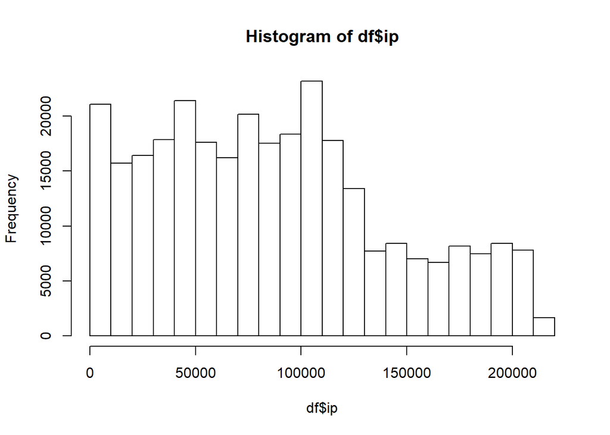

```r
# visualizando graficamente a distribuição por ip´s
hist(df$ip)
```

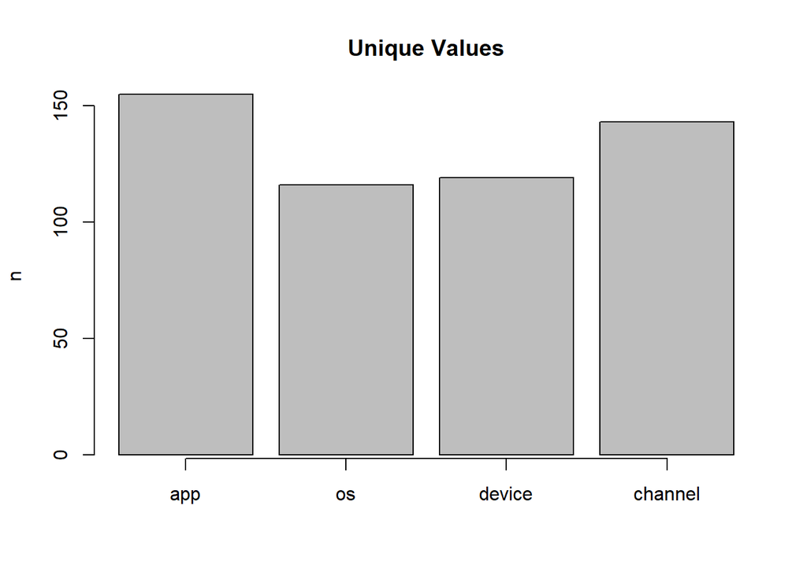

```r
# visualizando graficamente os valores únicos por variáveis
df_uniq <- as.vector(sapply(df[,c('app', 'os', 'device', 'channel')], function(x) as.numeric(length(unique(x)))))
barplot(df_uniq, main = "Unique Values", xlab = "", ylab = "n", names.arg = c('app', 'os', 'device', 'channel'), col = "grey", border = 1, axis.lty = 1)
```

Foi realizada uma análise gráfica de correlação entre algumas variáveis de negócio consideradas mais relevantes num primeiro momento, permitindo identificar visualmente um indício de possível relacionamento entre elas.

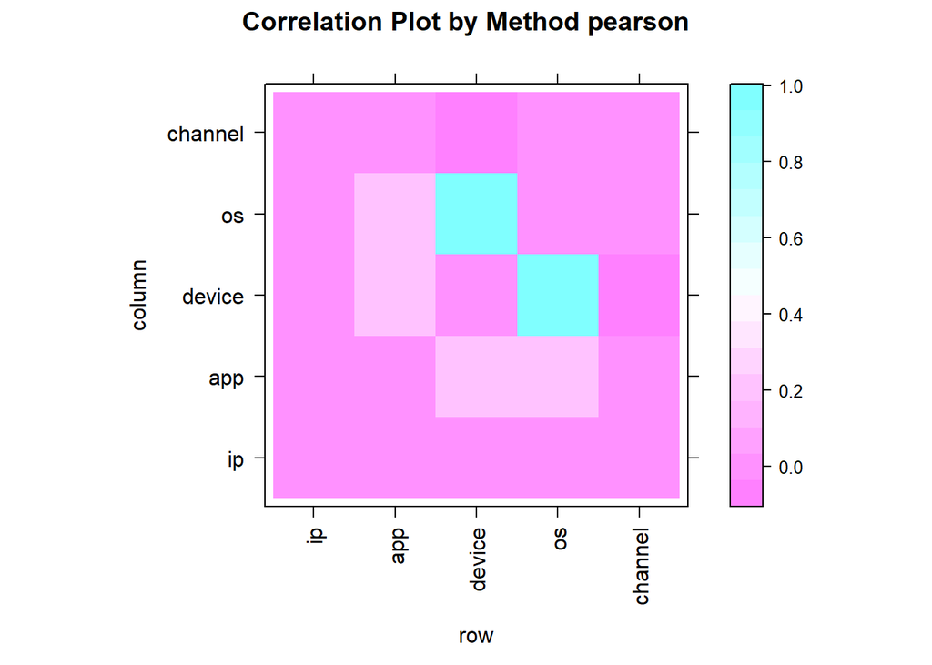

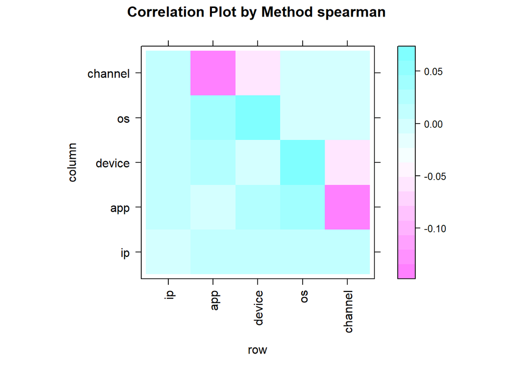

Foi realizada uma análise quantitativa do volume de cliques acima de 10 ocorrências para as variáveis ‘ip’, ‘app’ e ‘channel’ e agrupadas por ‘app’. Considerando que os dados estão contidos num mesmo dia, apenas em horários diferentes, identificou-se um grande volume de cliques de um mesmo ‘ip’ por ‘app’.

| app | ip | channel | n |
| --- | --- | --- | --- |
| 1 | 1256 | 134 | 16 |
| 1 | 1732 | 134 | 21 |
| 1 | 3093 | 125 | 12 |
| 1 | 3964 | 134 | 11 |
| 1 | 3994 | 134 | 19 |
| 1 | 5314 | 134 | 27 |

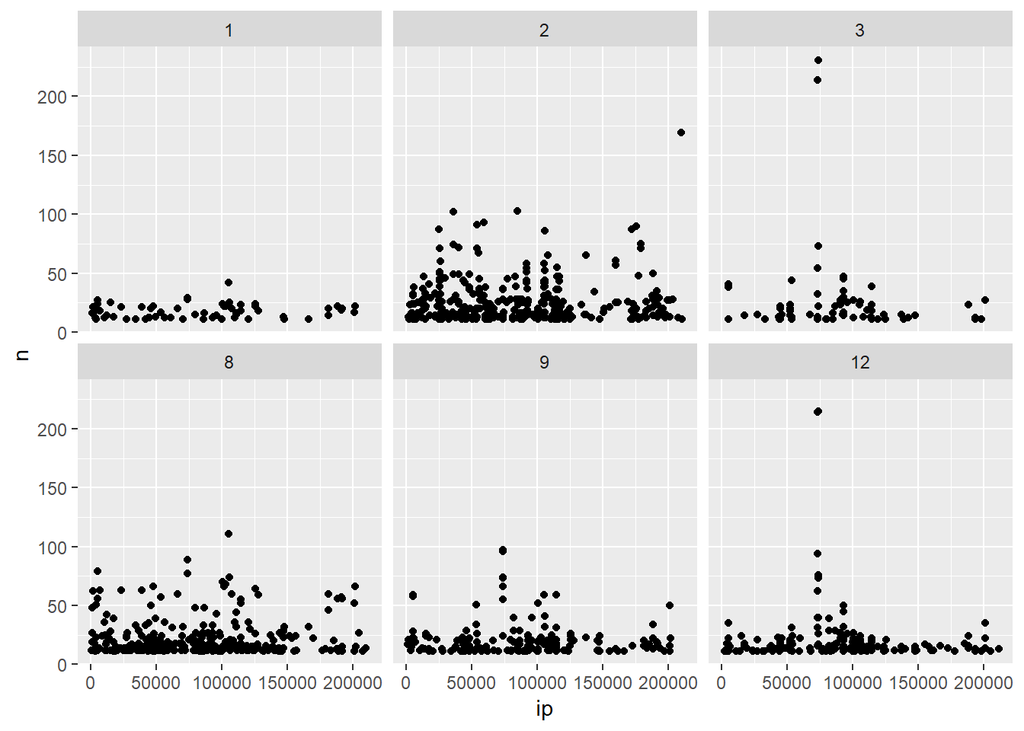

| app_ip_channel_os_device | n |
| --- | --- |
| 20_14901_259_17_1 | 61 |
| 24_14901_105_17_1 | 37 |
| 8_14901_259_17_1 | 28 |
| 9_14901_258_17_1 | 26 |
| 1_14901_125_17_1 | 25 |
| 9_14901_442_17_1 | 24 |

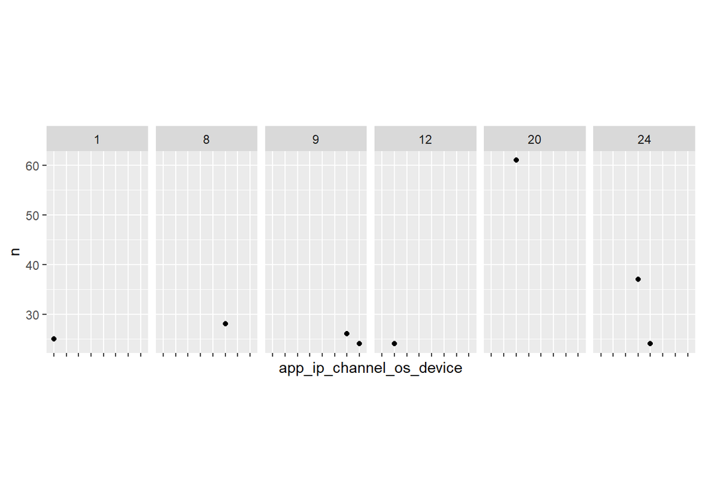

Conforme análises anteriores, foi verificado o volume de acessos no decorrer de um dia para um mesmo ‘ip’, constatando um grande volume de cliques em diversos horários independente do tipo de ‘app’ ou ‘channel’ envolvido, denotando mais um indício de possível fraude nos cliques.

| ip | time | n |
| --- | --- | --- |
| 198 | 16:00:18 | 1 |
| 198 | 16:00:29 | 3 |
| 198 | 16:00:30 | 1 |
| 198 | 16:00:35 | 2 |
| 198 | 16:00:50 | 1 |
| 198 | 16:01:01 | 1 |

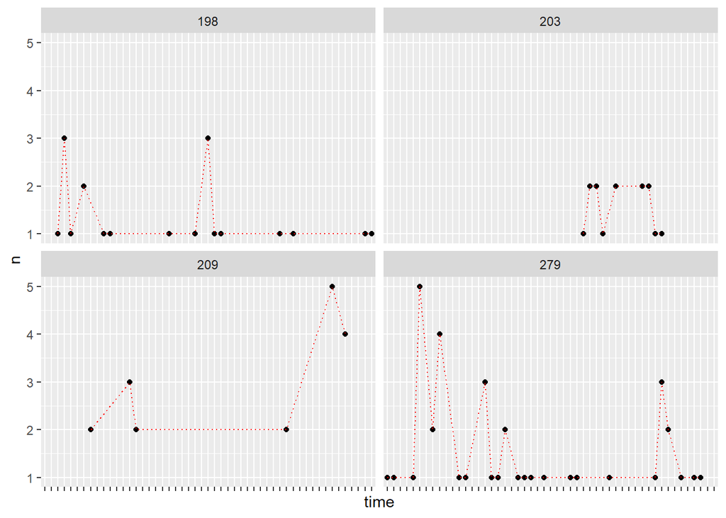

## Etapa 3 - Tratamento dos Dados

```r
# criando uma coluna ID
df <- mutate(df, click_id = row_number())

# removendo a variável attributed_time
df[,'attributed_time'] <- NULL
```

```r
# separando a variável click_time e verificando a necessidade de permanência da data
df$date <-as.numeric(as.POSIXct(df$click_time))
df$click_time <- NULL
```

```r
# criando a variável para predição
df$is_attributed <- factor(df$is_attributed, levels = c(1, 0), labels = c("Legal", "Fraude"))
str(df)
```

```
## 'data.frame':    300000 obs. of  8 variables:
##  $ ip           : int  83230 17357 35810 45745 161007 18787 103022 114221 165970 74544 ...
##  $ app          : int  3 3 3 14 3 3 3 3 3 64 ...
##  $ device       : int  1 1 1 1 1 1 1 1 1 1 ...
##  $ os           : int  13 19 13 13 13 16 23 19 13 22 ...
##  $ channel      : int  379 379 379 478 379 379 379 379 379 459 ...
##  $ is_attributed: Factor w/ 2 levels "Legal","Fraude": 2 2 2 2 2 2 2 2 2 2 ...
##  $ click_id     : int  1 2 3 4 5 6 7 8 9 10 ...
##  $ date         : num  1.51e+09 1.51e+09 1.51e+09 1.51e+09 1.51e+09 ...
```

```r
# Rededfinindo a lista de varáveis de negócio relevantes
col_names <- c('ip', 'app', 'device', 'os', 'channel', 'date')

# Verificando a proporção
round(prop.table(table(df$is_attributed)) * 100, digits = 1)
```

```
##
##  Legal Fraude
##    0.2   99.8
```

```r
# Normalizando os dados
summary(df)
```

```
##        ip              app             device              os
##  Min.   :     9   Min.   :  0.00   Min.   :   0.00   Min.   :  0.00
##  1st Qu.: 42103   1st Qu.:  3.00   1st Qu.:   1.00   1st Qu.: 13.00
##  Median : 81807   Median :  9.00   Median :   1.00   Median : 18.00
##  Mean   : 87062   Mean   : 11.98   Mean   :  25.82   Mean   : 23.27
##  3rd Qu.:121226   3rd Qu.: 15.00   3rd Qu.:   1.00   3rd Qu.: 19.00
##  Max.   :212773   Max.   :645.00   Max.   :3232.00   Max.   :715.00
##     channel      is_attributed      click_id           date
##  Min.   :  3.0   Legal :   522   Min.   :     1   Min.   :1.51e+09
##  1st Qu.:134.0   Fraude:299478   1st Qu.: 75001   1st Qu.:1.51e+09
##  Median :215.0                   Median :150001   Median :1.51e+09
##  Mean   :235.7                   Mean   :150001   Mean   :1.51e+09
##  3rd Qu.:280.0                   3rd Qu.:225000   3rd Qu.:1.51e+09
##  Max.   :498.0                   Max.   :300000   Max.   :1.51e+09
```

```r
df_norm <- as.data.frame(lapply(df[, col_names], normalize))
summary(df_norm)
```

```
##        ip              app               device                os
##  Min.   :0.0000   Min.   :0.000000   Min.   :0.0000000   Min.   :0.00000
##  1st Qu.:0.1978   1st Qu.:0.004651   1st Qu.:0.0003094   1st Qu.:0.01818
##  Median :0.3845   Median :0.013954   Median :0.0003094   Median :0.02517
##  Mean   :0.4092   Mean   :0.018581   Mean   :0.0079898   Mean   :0.03254
##  3rd Qu.:0.5697   3rd Qu.:0.023256   3rd Qu.:0.0003094   3rd Qu.:0.02657
##  Max.   :1.0000   Max.   :1.000000   Max.   :1.0000000   Max.   :1.00000
##     channel            date
##  Min.   :0.0000   Min.   :0.0000
##  1st Qu.:0.2646   1st Qu.:0.9527
##  Median :0.4283   Median :0.9681
##  Mean   :0.4701   Mean   :0.9686
##  3rd Qu.:0.5596   3rd Qu.:0.9850
##  Max.   :1.0000   Max.   :1.0000
```

```r
# retorna as variáveis
df_norm$is_attributed <-df$is_attributed
df_norm$click_id <- df$click_id
str(df_norm)
```

```
## 'data.frame':    300000 obs. of  8 variables:
##  $ ip           : num  0.3911 0.0815 0.1683 0.215 0.7567 ...
##  $ app          : num  0.00465 0.00465 0.00465 0.02171 0.00465 ...
##  $ device       : num  0.000309 0.000309 0.000309 0.000309 0.000309 ...
##  $ os           : num  0.0182 0.0266 0.0182 0.0182 0.0182 ...
##  $ channel      : num  0.76 0.76 0.76 0.96 0.76 ...
##  $ date         : num  0 0.013 0.0198 0.0269 0.0298 ...
##  $ is_attributed: Factor w/ 2 levels "Legal","Fraude": 2 2 2 2 2 2 2 2 2 2 ...
##  $ click_id     : int  1 2 3 4 5 6 7 8 9 10 ...
```

## Etapa 4 - Treinamento do modelo

Após o tratamento e normalização dos dados, inicia-se o processo de treinamento do modelo. Foram definidos 2 datasets com amostras randomizadas, sendo um de treino e outro de teste com 70% e 30% respectivamente dos dados originais.

```r
# define o índice das variáveis de predição e sequêncial
idx_target <- grep("is_attributed", colnames(df_norm))
idx_sequence <- grep("click_id", colnames(df_norm))

# Criando as amostras de forma randômica
df_sample <- get_dataset_train_test(df_norm, test_pct = 30, target_idx = idx_target, sequence_idx = idx_sequence)
```

```r
# Criando dados de treino
df_train.data <- df_sample$traindata
df_train.dir <- df_sample$traindir
df_train.seq <- df_sample$trainseq

# Criando dados de teste
df_test.data <- df_sample$testdata
df_test.dir <- df_sample$testdir
df_test.seq <- df_sample$testseq
```

```r
# Executando o modelo
model_result <- knn(train = df_train.data,test = df_test.data,cl = df_train.dir,k = 20)
```

## Etapa 5 - Avaliação da Performance do modelo

```r
# Exibe os resultados da predição
CrossTable(x = df_test.dir, y = model_result, prop.chisq = FALSE)
```

```
##
##
##    Cell Contents
## |-------------------------|
## |                       N |
## |           N / Row Total |
## |           N / Col Total |
## |         N / Table Total |
## |-------------------------|
##
##
## Total Observations in Table:  90000
##
##
##              | model_result
##  df_test.dir |     Legal |    Fraude | Row Total |
## -------------|-----------|-----------|-----------|
##        Legal |         4 |       151 |       155 |
##              |     0.026 |     0.974 |     0.002 |
##              |     0.500 |     0.002 |           |
##              |     0.000 |     0.002 |           |
## -------------|-----------|-----------|-----------|
##       Fraude |         4 |     89841 |     89845 |
##              |     0.000 |     1.000 |     0.998 |
##              |     0.500 |     0.998 |           |
##              |     0.000 |     0.998 |           |
## -------------|-----------|-----------|-----------|
## Column Total |         8 |     89992 |     90000 |
##              |     0.000 |     1.000 |           |
## -------------|-----------|-----------|-----------|
##
##
```

```
## [1] "Taxa de acerto do Modelo: 99.83%"
```

```r
# Interpretando os Resultados
#
# A tabela cruzada mostra 4 possíveis valores, que representam os falso/verdadeiro positivo e negativo.
#
# A primeira coluna lista os labels originais nos dados observados e as duas colunas
# seguintes do modelo (Fraude e Legal), mostram os resultados da previsão.
#
# Temos:
#  Cenário 1: Célula Legal (label)  x Legal (Modelo) - True Positive (Legal como Legal)
#  Cenário 2: Célula Legal (label)  x Fraude (Modelo) - False Negative (Fraude como Legal)
#  Cenário 3: Célula Fraude (label) x Legal (Modelo) - False Positive (Legal como Fraude)
#  Cenário 4: Célula Fraude (label) x Fraude (Modelo) - True Negative (Fraude como Fraude)
#
# Lendo a Confusion Matrix (Perspectiva de ser um click fraudulento ou não):
#  Falso Negativo = Click Fraude considerado incorretamente como Legal
#  Falso Positivo = Click Legal considerado incorretamente como Fraude
#  True Negative  = Click Fraude considerado corretamente como Fraude
#  True Positive  = Click Legal considerado corretamente como Legal
#
```

## Etapa 6 - Otimização do modelo

```r
# variável excluída
col_names_excl <- c('os', 'date')
idx_col_excl <- grep("os", colnames(df))
df_excl <- df[,-idx_col_excl]

# Redefinindo os índices
idx_target <- grep("is_attributed", colnames(df_excl))
idx_sequence <- grep("click_id", colnames(df_excl))

# Padronizando o z-score
df_norm_z <- as.data.frame(scale(df_excl[,-c(idx_target, idx_sequence)]))
summary(df_norm_z)
```

```
##        ip                app              device            channel
##  Min.   :-1.56397   Min.   :-0.6958   Min.   :-0.09496   Min.   :-1.9209
##  1st Qu.:-0.80772   1st Qu.:-0.5217   1st Qu.:-0.09128   1st Qu.:-0.8395
##  Median :-0.09441   Median :-0.1733   Median :-0.09128   Median :-0.1708
##  Mean   : 0.00000   Mean   : 0.0000   Mean   : 0.00000   Mean   : 0.0000
##  3rd Qu.: 0.61379   3rd Qu.: 0.1751   3rd Qu.:-0.09128   3rd Qu.: 0.3657
##  Max.   : 2.25850   Max.   :36.7534   Max.   :11.79006   Max.   : 2.1654
##       date
##  Min.   :-43.29835
##  1st Qu.: -0.70998
##  Median : -0.02397
##  Mean   :  0.00000
##  3rd Qu.:  0.73383
##  Max.   :  1.40388
```

```r
df_norm_z$is_attributed <- df_excl[,idx_target]
df_norm_z$click_id <- df_excl[,idx_sequence]
str(df_norm_z)
```

```
## 'data.frame':    300000 obs. of  7 variables:
##  $ ip           : num  -0.0688 -1.2523 -0.9208 -0.7423 1.3285 ...
##  $ app          : num  -0.522 -0.522 -0.522 0.117 -0.522 ...
##  $ device       : num  -0.0913 -0.0913 -0.0913 -0.0913 -0.0913 ...
##  $ channel      : num  1.18 1.18 1.18 2 1.18 ...
##  $ date         : num  -43.3 -42.7 -42.4 -42.1 -42 ...
##  $ is_attributed: Factor w/ 2 levels "Legal","Fraude": 2 2 2 2 2 2 2 2 2 2 ...
##  $ click_id     : int  1 2 3 4 5 6 7 8 9 10 ...
```

```r
# Redefinindo os índices
idx_target <- grep("is_attributed", colnames(df_norm_z))
idx_sequence <- grep("click_id", colnames(df_norm_z))

# Criando as amostras de forma randômica
df_sample <- get_dataset_train_test(df_norm_z, test_pct = 30, target_idx = idx_target, sequence_idx = idx_sequence)
```

```r
# Criando dados de treino
df_train.data <- df_sample$traindata
df_train.dir <- df_sample$traindir
df_train.seq <- df_sample$trainseq

# Criando dados de teste
df_test.data <- df_sample$testdata
df_test.dir <- df_sample$testdir
df_test.seq <- df_sample$testseq
```

```r
# Executa a predição
model_result.pred <- knn(train = df_train.data,test = df_test.data,cl = df_train.dir,k = 20, prob = TRUE)
```

## Etapa 7 - Avaliação dos Resultados e Taxa de Erro

```r
# Exibe os resultados da predição
CrossTable(x = df_test.dir, y = model_result.pred, prop.chisq = FALSE)
```

```
##
##
##    Cell Contents
## |-------------------------|
## |                       N |
## |           N / Row Total |
## |           N / Col Total |
## |         N / Table Total |
## |-------------------------|
##
##
## Total Observations in Table:  90000
##
##
##              | model_result.pred
##  df_test.dir |     Legal |    Fraude | Row Total |
## -------------|-----------|-----------|-----------|
##        Legal |         2 |       153 |       155 |
##              |     0.013 |     0.987 |     0.002 |
##              |     0.333 |     0.002 |           |
##              |     0.000 |     0.002 |           |
## -------------|-----------|-----------|-----------|
##       Fraude |         4 |     89841 |     89845 |
##              |     0.000 |     1.000 |     0.998 |
##              |     0.667 |     0.998 |           |
##              |     0.000 |     0.998 |           |
## -------------|-----------|-----------|-----------|
## Column Total |         6 |     89994 |     90000 |
##              |     0.000 |     1.000 |           |
## -------------|-----------|-----------|-----------|
##
##
```

```
## [1] "Taxa de acerto do Modelo: 99.83%"
```

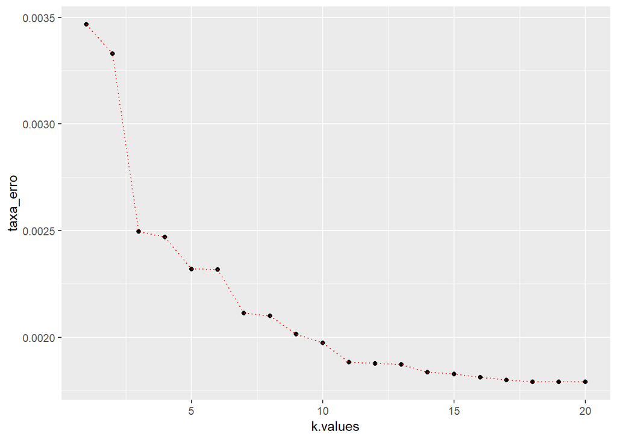

[figure not shown]

```r
# A medida que o valor de k aumenta, a taxa de erro do modelo tende a diminir
ggplot(df_erro, aes(x = k.values, y = taxa_erro)) + geom_point()+ geom_line(lty = "dotted", color = 'red')
```